# 8. Modern Convolutional Neural Networks

- Show All Code
- Hide All Code
- View Source

Dive-into-Deep-Learning

Introduction to the modern convolutional neural networks: AlexNet, VGG, NiN, GoogleNet, LeNet with BN, ResNet and DenseNet, and their implementations on the FashionMNIST.

Author

Wu Hao

Published

2025/2/16

```python
import torch
from torch import nn
from d2l import torch as d2l
import torchvision
from torch.utils import data
from torch.utils.data import DataLoader
from torchvision import transforms
import time
import numpy as np
from torch.nn import functional as F
```

# GPU and Config

```python
device = 'cuda' if torch.cuda.is_available() else 'cpu'

config_AlexNet = {
    'n_epochs': 10,     # Number of epochs.
    'batch_size': 128,
    'learning_rate': 1e-3,
}

config_VGG = {
    'n_epochs': 10,     # Number of epochs.
    'batch_size': 128,
    'learning_rate': 1e-3,
}

config_NiN = {
    'n_epochs': 10,     # Number of epochs.
    'batch_size': 128,
    'learning_rate': 1e-3,
}

config_GoogLeNet = {
    'n_epochs': 10,     # Number of epochs.
    'batch_size': 128,
    'learning_rate': 1e-3,
}

config_LeNet_BN = {
    'n_epochs': 10,     # Number of epochs.
    'batch_size': 256,
    'learning_rate': 1e-3,
}

config_ResNet = {
    'n_epochs': 10,     # Number of epochs.
    'batch_size': 128,
    'learning_rate': 1e-3,
}

config_DenseNet = {
    'n_epochs': 10,     # Number of epochs.
    'batch_size': 128,
    'learning_rate': 1e-3,
}
```

### Preprocessing the Data

```python
def ImgDataloader(config, shape = None):
    if not shape:
        trans = transforms.Compose([
        transforms.ToTensor()
        ])
    else:
        trans = transforms.Compose([
        transforms.ToTensor(),
        transforms.Resize(shape)
        ])

    mnist_train = torchvision.datasets.FashionMNIST(root="./data", train=True, transform=trans, download = True)
    mnist_test = torchvision.datasets.FashionMNIST(root="./data", train=False, transform=trans, download = True)

    train_len = len(mnist_train)
    test_len = len(mnist_test)

    train_iter = DataLoader(mnist_train, config['batch_size'], shuffle= True)
    test_iter = DataLoader(mnist_test, config['batch_size'])
    return train_iter, test_iter, train_len, test_len
```

# AlexNet

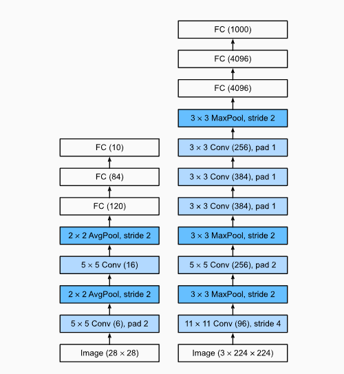

From LeNet (left) to AlexNet (right)

## Key Innovations of AlexNet

1. Deeper Network Architecture

Compared to the LeNet-5, AlexNet introduced an 8-layer deep CNN (5 convolutional layers + 3 fully connected layers). The increased depth allowed the model to learn more complex features, leading to higher classification accuracy.

2. Use of ReLU (Rectified Linear Unit) Activation Function

Traditional networks used sigmoid or tanh activation functions, which suffered from the vanishing gradient problem, making deep networks hard to train. AlexNet used ReLU, which has a simple max(0, x) function. This helped accelerate training by mitigating the vanishing gradient issue.

3. GPU Acceleration for Training

Training a deep network like AlexNet requires massive computational power. Instead of using CPUs, the team leveraged NVIDIA GTX 580 GPUs, significantly speeding up training. This was the first large-scale deep learning model to successfully use GPU acceleration, setting the stage for future deep learning advancements.

4. Overlapping Max Pooling

Previous CNNs used non-overlapping pooling, where pooling regions did not overlap. AlexNet introduced overlapping pooling, where pooling windows had partial overlap.

5. Dropout for Regularization

Deep networks with many parameters are prone to overfitting. AlexNet introduced Dropout, a technique where neurons are randomly dropped during training. This prevents co-adaptation of features and improves generalization.

6. Data Augmentation

To combat overfitting, AlexNet applied data augmentation techniques, including: Random cropping, Horizontal flipping and Color perturbations (brightness, contrast, and saturation changes). These techniques artificially increased the dataset size, improving generalization.

7. Local Response Normalization (LRN) AlexNet introduced Local Response Normalization (LRN), which normalizes activations across neighboring neurons. It was designed to enhance competition between neurons and improve generalization. However, later research found that Batch Normalization (BN) is more effective, and LRN is now rarely used.

## Implementation of AlexNet

```python
def init_weights(m):
    if type(m) == nn.Linear or type(m) == nn.Conv2d:
        nn.init.xavier_uniform_(m.weight)

class AlexNet(d2l.Classifier):
    def __init__(self, lr=0.1, num_classes=10):
        super().__init__()
        self.save_hyperparameters()
        self.net = nn.Sequential(
            nn.LazyConv2d(96, kernel_size=11, stride=4, padding=1),
            nn.ReLU(), nn.MaxPool2d(kernel_size=3, stride=2),
            nn.LazyConv2d(256, kernel_size=5, padding=2), nn.ReLU(),
            nn.MaxPool2d(kernel_size=3, stride=2),
            nn.LazyConv2d(384, kernel_size=3, padding=1), nn.ReLU(),
            nn.LazyConv2d(384, kernel_size=3, padding=1), nn.ReLU(),
            nn.LazyConv2d(256, kernel_size=3, padding=1), nn.ReLU(),
            nn.MaxPool2d(kernel_size=3, stride=2), nn.Flatten(),
            nn.LazyLinear(4096), nn.ReLU(), nn.Dropout(p=0.5),
            nn.LazyLinear(4096), nn.ReLU(),nn.Dropout(p=0.5),
            nn.LazyLinear(num_classes))
        self.net.apply(d2l.init_cnn)
    def layer_summary(self, X_shape):
            X = torch.randn(*X_shape)
            for layer in self.net:
                X = layer(X)
                print(layer.__class__.__name__, 'output shape:\t', X.shape)
```

We construct a single-channel data example with both height and width of 224 to observe the output shape of each layer.

```python
AlexNet().layer_summary((1, 1, 224, 224))
```

```
Conv2d output shape:     torch.Size([1, 96, 54, 54])
ReLU output shape:   torch.Size([1, 96, 54, 54])
MaxPool2d output shape:  torch.Size([1, 96, 26, 26])
Conv2d output shape:     torch.Size([1, 256, 26, 26])
ReLU output shape:   torch.Size([1, 256, 26, 26])
MaxPool2d output shape:  torch.Size([1, 256, 12, 12])
Conv2d output shape:     torch.Size([1, 384, 12, 12])
ReLU output shape:   torch.Size([1, 384, 12, 12])
Conv2d output shape:     torch.Size([1, 384, 12, 12])
ReLU output shape:   torch.Size([1, 384, 12, 12])
Conv2d output shape:     torch.Size([1, 256, 12, 12])
ReLU output shape:   torch.Size([1, 256, 12, 12])
MaxPool2d output shape:  torch.Size([1, 256, 5, 5])
Flatten output shape:    torch.Size([1, 6400])
Linear output shape:     torch.Size([1, 4096])
ReLU output shape:   torch.Size([1, 4096])
Dropout output shape:    torch.Size([1, 4096])
Linear output shape:     torch.Size([1, 4096])
ReLU output shape:   torch.Size([1, 4096])
Dropout output shape:    torch.Size([1, 4096])
Linear output shape:     torch.Size([1, 10])
```

## Training

Now that we have implemented the model, let’s run an experiment to see how the AlexNet model fares on Fashion-MNIST.

### Start Training

```python
def trainer(train_iter, test_iter, train_len, test_len, model, config, device):

    #optimization algorithm.
    optimizer = torch.optim.Adam(model.parameters(), lr=config['learning_rate'])
    criterion = nn.CrossEntropyLoss()
    model.apply(init_weights)
    print('training on', device)
    model.to(device)

    n_epochs= config['n_epochs']

    for epoch in range(n_epochs):
        model.train()
        epoch_start_time = time.time()
        loss_record = []
        train_acc = 0.0
        #x: features, y: labels
        for X, y in train_iter:
            optimizer.zero_grad()               # Set gradient to zero.
            X, y = X.to(device), y.to(device)
            train_pred = model(X)
            batch_loss = criterion(train_pred, y)
            batch_loss.backward()               # Compute gradient(back propagation).
            optimizer.step()                    # Update parameters.
            train_acc += np.sum(np.argmax(train_pred.detach().cpu().numpy(), axis=1) == y.cpu().numpy())
            loss_record.append(batch_loss.detach().item()) #detach(): separation gradient

        mean_train_loss = sum(loss_record)/len(loss_record)
        train_acc = train_acc / train_len

        model.eval() # Set our model to evaluation mode.
        loss_record = []
        test_acc = 0.0
        with torch.no_grad():
            for x, y in test_iter:
                x, y = x.to(device), y.to(device)
                test_pred = model(x)
                batch_loss = criterion(test_pred, y)
                test_acc += np.sum(np.argmax(test_pred.detach().cpu().numpy(), axis=1) == y.cpu().numpy())
                loss_record.append(batch_loss.item())

            mean_test_loss = sum(loss_record)/len(loss_record)
            test_acc = test_acc / test_len
            print('[%03d/%03d] %2.2f sec(s) Train Acc: %3.6f Loss: %3.6f | Test Acc: %3.6f loss: %3.6f' % \
              (epoch + 1, n_epochs, time.time() - epoch_start_time, \
               train_acc, mean_train_loss, test_acc, mean_test_loss))
```

```python
train_iter, test_iter, train_len, test_len = ImgDataloader(config_AlexNet, shape=(224,224))
model = AlexNet()
trainer(train_iter, test_iter, train_len, test_len, model, config_AlexNet, device)
```

```
training on cuda
[001/010] 29.94 sec(s) Train Acc: 0.748950 Loss: 0.656770 | Test Acc: 0.855800 loss: 0.382683
[002/010] 29.44 sec(s) Train Acc: 0.867850 Loss: 0.354673 | Test Acc: 0.878900 loss: 0.326185
[003/010] 30.11 sec(s) Train Acc: 0.884683 Loss: 0.307233 | Test Acc: 0.874400 loss: 0.346100
[004/010] 30.58 sec(s) Train Acc: 0.895917 Loss: 0.278345 | Test Acc: 0.892800 loss: 0.293821
[005/010] 29.76 sec(s) Train Acc: 0.904950 Loss: 0.253805 | Test Acc: 0.891400 loss: 0.298870
[006/010] 29.66 sec(s) Train Acc: 0.912433 Loss: 0.236694 | Test Acc: 0.911000 loss: 0.250300
[007/010] 29.83 sec(s) Train Acc: 0.917367 Loss: 0.219314 | Test Acc: 0.908300 loss: 0.255789
[008/010] 30.37 sec(s) Train Acc: 0.922267 Loss: 0.209271 | Test Acc: 0.914300 loss: 0.246779
[009/010] 29.78 sec(s) Train Acc: 0.926600 Loss: 0.195510 | Test Acc: 0.902000 loss: 0.273193
[010/010] 29.47 sec(s) Train Acc: 0.929500 Loss: 0.187447 | Test Acc: 0.912700 loss: 0.254202
```

# VGG (Networks Using Blocks)

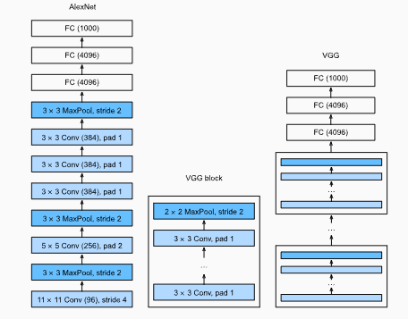

From AlexNet to VGG

## Key Innovations of VGG

1. Increased Depth with Smaller Filters

Unlike AlexNet, which had 8 layers, VGG significantly increased the depth to 16 or 19 layers (VGG-16, VGG-19). It replaced large receptive field filters (e.g., $11 \times 11$ and $5 \times 5$ in AlexNet) with multiple $3 \times 3$ filters stacked sequentially.

2. Uniform Architecture

VGG used a very consistent design: All convolution layers use 3×3 kernels with stride 1; All pooling layers use 2×2 max-pooling with stride 2. This uniformity made the architecture more modular and easier to generalize to new architectures.

3. More Feature Maps (Channels)

VGG progressively increased the number of feature maps (starting from 64 and doubling after each pooling layer: 64 → 128 → 256 → 512). This allowed it to capture more detailed hierarchical features.

4. Removal of Local Response Normalization (LRN)

AlexNet introduced Local Response Normalization (LRN) to encourage competition between neurons.However, VGG found that simply increasing depth was more effective, and batch normalization (BN) later replaced LRN in deep learning models.

## VGG Blocks

The function below takes two arguments, corresponding to the number of convolutional layers `num_convs` and the number of output channels `num_channels`.

```python
def vgg_block(num_convs, out_channels):
    layers = []
    for _ in range(num_convs):
        layers.append(nn.LazyConv2d(out_channels, kernel_size=3, padding=1))
        layers.append(nn.ReLU())
    layers.append(nn.MaxPool2d(kernel_size=2,stride=2))
    return nn.Sequential(*layers)
```

The original VGG network had five convolutional blocks, among which the first two have one convolutional layer each and the latter three contain two convolutional layers each. The first block has 64 output channels and each subsequent block doubles the number of output channels, until that number reaches 512. Since this network uses eight convolutional layers and three fully connected layers, it is often called *VGG-11*.

```python
class VGG(d2l.Classifier):
    def __init__(self, arch, lr=0.1, num_classes=10):
        super().__init__()
        self.save_hyperparameters()
        conv_blks = []
        for (num_convs, out_channels) in arch:
            conv_blks.append(vgg_block(num_convs, out_channels))
        self.net = nn.Sequential(
            *conv_blks, nn.Flatten(),
            nn.LazyLinear(4096), nn.ReLU(), nn.Dropout(0.5),
            nn.LazyLinear(4096), nn.ReLU(), nn.Dropout(0.5),
            nn.LazyLinear(num_classes))
        self.net.apply(d2l.init_cnn)
    def layer_summary(self, X_shape):
            X = torch.randn(*X_shape)
            for layer in self.net:
                X = layer(X)
                print(layer.__class__.__name__, 'output shape:\t', X.shape)

conv_arch = ((1, 64), (1, 128), (2, 256), (2, 512), (2, 512))
vgg_net = VGG(conv_arch)
vgg_net.layer_summary((1, 1, 224, 224))
```

```
Sequential output shape:     torch.Size([1, 64, 112, 112])
Sequential output shape:     torch.Size([1, 128, 56, 56])
Sequential output shape:     torch.Size([1, 256, 28, 28])
Sequential output shape:     torch.Size([1, 512, 14, 14])
Sequential output shape:     torch.Size([1, 512, 7, 7])
Flatten output shape:    torch.Size([1, 25088])
Linear output shape:     torch.Size([1, 4096])
ReLU output shape:   torch.Size([1, 4096])
Dropout output shape:    torch.Size([1, 4096])
Linear output shape:     torch.Size([1, 4096])
ReLU output shape:   torch.Size([1, 4096])
Dropout output shape:    torch.Size([1, 4096])
Linear output shape:     torch.Size([1, 10])
```

## Training

```python
train_iter, test_iter, train_len, test_len = ImgDataloader(config_VGG, shape=(224,224))
model = VGG(conv_arch)
trainer(train_iter, test_iter, train_len, test_len, model, config_VGG, device)
```

```
training on cuda
[001/010] 136.69 sec(s) Train Acc: 0.753833 Loss: 0.645351 | Test Acc: 0.875800 loss: 0.336631
[002/010] 137.09 sec(s) Train Acc: 0.882850 Loss: 0.318672 | Test Acc: 0.890900 loss: 0.297262
[003/010] 136.77 sec(s) Train Acc: 0.902750 Loss: 0.266168 | Test Acc: 0.906000 loss: 0.266387
[004/010] 137.10 sec(s) Train Acc: 0.914183 Loss: 0.232582 | Test Acc: 0.908200 loss: 0.246646
[005/010] 136.95 sec(s) Train Acc: 0.921483 Loss: 0.210667 | Test Acc: 0.915400 loss: 0.238278
[006/010] 136.68 sec(s) Train Acc: 0.929917 Loss: 0.190004 | Test Acc: 0.922000 loss: 0.216905
[007/010] 136.93 sec(s) Train Acc: 0.937517 Loss: 0.167049 | Test Acc: 0.919900 loss: 0.232752
[008/010] 136.26 sec(s) Train Acc: 0.942833 Loss: 0.153093 | Test Acc: 0.925600 loss: 0.226179
[009/010] 137.36 sec(s) Train Acc: 0.950817 Loss: 0.135656 | Test Acc: 0.927900 loss: 0.212950
[010/010] 136.60 sec(s) Train Acc: 0.954850 Loss: 0.123782 | Test Acc: 0.925800 loss: 0.219024
```

# NiN (Network in Network)

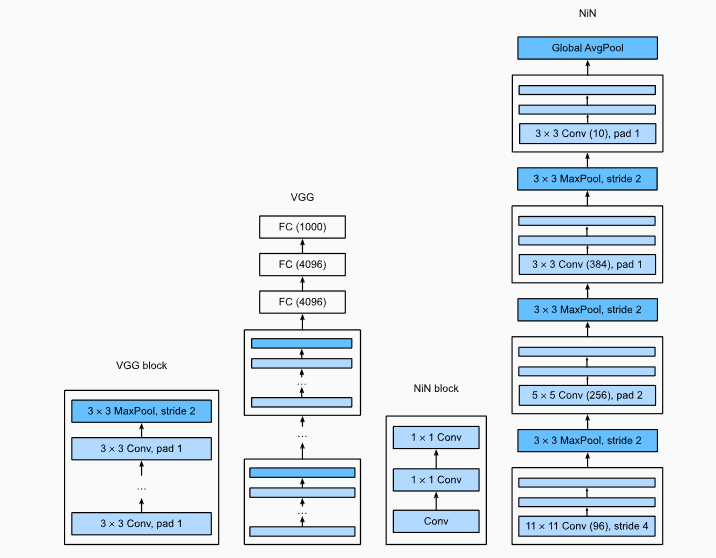

Comparing the architectures of VGG and NiN, and of their blocks

## Key Innovations of NiN

### $1 \times 1$ Convolution (MLPConvolution)

Instead of using only large convolution kernels (like 5×5 in AlexNet or multiple 3×3 in VGG), NiN introduced 1×1 convolutions, treating each pixel as a small “fully connected network”. This acts as a Multi-Layer Perceptron (MLP) applied to each pixel, which is why NiN is sometimes called MLPConv. The advantages of $1 \times 1$ Convolution:

1. Dimensionality Reduction:

A traditional NxN filter with $C_{in}$ input channels produces $N \times N \times C_{in} \times C_{out}$ parameters. Using a 1×1 convolution significantly reduces the number of parameters while still capturing complex patterns.

2. Increased Non-linearity:

Each 1×1 convolution is followed by a ReLU activation, increasing the network’s ability to learn complex patterns.

3. Better Channel-Wise Feature Mixing:

Traditional convolutions operate spatially (across neighboring pixels), but 1×1 convolutions allow information exchange between different channels, improving feature representation.

### Global Average Pooling (GAP)

In AlexNet and VGG, the final layers consist of fully connected (FC) layers with thousands of parameters, leading to high memory consumption and overfitting.

**Why is GAP Better than Fully Connected Layers?**

1. No Large FC Layers → Fewer Parameters → Less Overfitting.
2. GAP Enforces Spatial Invariance (FC layers tend to overfit by memorizing exact positions).
3. No Need for Dropout → Since GAP naturally prevents overfitting, the explicit use of dropout (as in AlexNet) is not necessary.

## Implementation of NiN

### NiN Blocks

```python
def nin_block(out_channels, kernel_size, strides, padding):
    return nn.Sequential(
        nn.LazyConv2d(out_channels, kernel_size, strides, padding), nn.ReLU(),
        nn.LazyConv2d(out_channels, kernel_size=1), nn.ReLU(),
        nn.LazyConv2d(out_channels, kernel_size=1), nn.ReLU())
```

### NiN Model

```python
class NiN(d2l.Classifier):
    def __init__(self, lr=0.1, num_classes=10):
        super().__init__()
        self.save_hyperparameters()
        self.net = nn.Sequential(
            nin_block(96, kernel_size=11, strides=4, padding=0),
            nn.MaxPool2d(3, stride=2),
            nin_block(256, kernel_size=5, strides=1, padding=2),
            nn.MaxPool2d(3, stride=2),
            nin_block(384, kernel_size=3, strides=1, padding=1),
            nn.MaxPool2d(3, stride=2),
            nn.Dropout(0.5),
            nin_block(num_classes, kernel_size=3, strides=1, padding=1),
            nn.AdaptiveAvgPool2d((1, 1)),
            nn.Flatten())
    def layer_summary(self, X_shape):
            X = torch.randn(*X_shape)
            for layer in self.net:
                X = layer(X)
                print(layer.__class__.__name__, 'output shape:\t', X.shape)

NiN().layer_summary((1, 1, 224, 224))
```

```
Sequential output shape:     torch.Size([1, 96, 54, 54])
MaxPool2d output shape:  torch.Size([1, 96, 26, 26])
Sequential output shape:     torch.Size([1, 256, 26, 26])
MaxPool2d output shape:  torch.Size([1, 256, 12, 12])
Sequential output shape:     torch.Size([1, 384, 12, 12])
MaxPool2d output shape:  torch.Size([1, 384, 5, 5])
Dropout output shape:    torch.Size([1, 384, 5, 5])
Sequential output shape:     torch.Size([1, 10, 5, 5])
AdaptiveAvgPool2d output shape:  torch.Size([1, 10, 1, 1])
Flatten output shape:    torch.Size([1, 10])
```

## Training

```python
train_iter, test_iter, train_len, test_len = ImgDataloader(config_NiN, shape=(224,224))
model = NiN()
trainer(train_iter, test_iter, train_len, test_len, model, config_NiN, device)
```

```
training on cuda
[001/010] 30.32 sec(s) Train Acc: 0.537350 Loss: 1.274015 | Test Acc: 0.741300 loss: 0.715626
[002/010] 29.93 sec(s) Train Acc: 0.773017 Loss: 0.624269 | Test Acc: 0.776700 loss: 0.588347
[003/010] 30.10 sec(s) Train Acc: 0.817250 Loss: 0.501794 | Test Acc: 0.835800 loss: 0.451094
[004/010] 29.69 sec(s) Train Acc: 0.835817 Loss: 0.447641 | Test Acc: 0.826100 loss: 0.460402
[005/010] 30.09 sec(s) Train Acc: 0.847250 Loss: 0.419191 | Test Acc: 0.856900 loss: 0.394029
[006/010] 30.05 sec(s) Train Acc: 0.857433 Loss: 0.389221 | Test Acc: 0.864400 loss: 0.370759
[007/010] 30.04 sec(s) Train Acc: 0.865867 Loss: 0.366980 | Test Acc: 0.868100 loss: 0.359708
[008/010] 29.99 sec(s) Train Acc: 0.874733 Loss: 0.342656 | Test Acc: 0.876900 loss: 0.351876
[009/010] 30.37 sec(s) Train Acc: 0.882267 Loss: 0.323778 | Test Acc: 0.883800 loss: 0.318817
[010/010] 30.14 sec(s) Train Acc: 0.889883 Loss: 0.303711 | Test Acc: 0.888700 loss: 0.309745
```

## Discussion

Why is the performance of NiN on FashionMNIST worse than VGG?

# Multi-Branch Networks (GoogLeNet)

The basic convolutional block in GoogLeNet is called an *Inception block*, stemming from the meme “we need to go deeper” from the movie Inception.

## Key Innovations of GoogLeNet

### The Inception Module: Multi-scale Feature Extraction

Instead of using only one type of convolution (e.g., all 3×3 or all 5×5) like VGG, GoogLeNet introduced the Inception module, which performs multiple convolutions of different sizes (1×1, 3×3, 5×5) and pooling in parallel.

This allows the network to capture both fine-grained local features (from 1×1 and 3×3 convolutions) and more abstract global features (from 5×5 convolutions and pooling).

1. Use large filters (e.g., 5×5, 7×7) → High computational cost.
2. Use small filters (e.g., 3×3) → May not capture large-scale features effectively.

Inception solves this by combining multiple filter sizes in parallel, allowing the network to adaptively learn which scale is most important.

## Implementation of GoogLeNet

### Inception Blocks

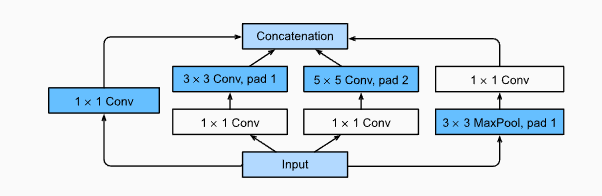

Structure of the Inception block

```python
class Inception(nn.Module):
    # c1--c4 are the number of output channels for each branch
    def __init__(self, c1, c2, c3, c4, **kwargs):
        super(Inception, self).__init__(**kwargs)
        # Branch 1
        self.b1_1 = nn.LazyConv2d(c1, kernel_size=1)
        # Branch 2
        self.b2_1 = nn.LazyConv2d(c2[0], kernel_size=1)
        self.b2_2 = nn.LazyConv2d(c2[1], kernel_size=3, padding=1)
        # Branch 3
        self.b3_1 = nn.LazyConv2d(c3[0], kernel_size=1)
        self.b3_2 = nn.LazyConv2d(c3[1], kernel_size=5, padding=2)
        # Branch 4
        self.b4_1 = nn.MaxPool2d(kernel_size=3, stride=1, padding=1)
        self.b4_2 = nn.LazyConv2d(c4, kernel_size=1)

    def forward(self, x):
        b1 = F.relu(self.b1_1(x))
        b2 = F.relu(self.b2_2(F.relu(self.b2_1(x))))
        b3 = F.relu(self.b3_2(F.relu(self.b3_1(x))))
        b4 = F.relu(self.b4_2(self.b4_1(x)))
        return torch.cat((b1, b2, b3, b4), dim=1)
```

### GoogLeNet Model

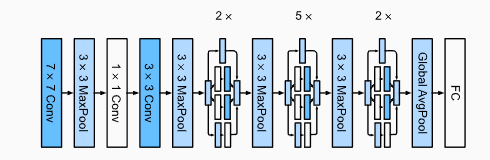

The GoogLeNet architecture

```python
class GoogLeNet(d2l.Classifier):
    def b1(self):
        return nn.Sequential(
            nn.LazyConv2d(64, kernel_size=7, stride=2, padding=3),
            nn.ReLU(), nn.MaxPool2d(kernel_size=3, stride=2, padding=1))
    def b2(self):
        return nn.Sequential(
            nn.LazyConv2d(64, kernel_size=1), nn.ReLU(),
            nn.LazyConv2d(192, kernel_size=3, padding=1), nn.ReLU(),
            nn.MaxPool2d(kernel_size=3, stride=2, padding=1))
    def b3(self):
        return nn.Sequential(
            Inception(64, (96, 128), (16, 32), 32),
            Inception(128, (128, 192), (32, 96), 64),
            nn.MaxPool2d(kernel_size=3, stride=2, padding=1))
    def b4(self):
        return nn.Sequential(
            Inception(192, (96, 208), (16, 48), 64),
            Inception(160, (112, 224), (24, 64), 64),
            Inception(128, (128, 256), (24, 64), 64),
            Inception(112, (144, 288), (32, 64), 64),
            Inception(256, (160, 320), (32, 128), 128),
            nn.MaxPool2d(kernel_size=3, stride=2, padding=1))
    def b5(self):
        return nn.Sequential(
            Inception(256, (160, 320), (32, 128), 128),
            Inception(384, (192, 384), (48, 128), 128),
            nn.AdaptiveAvgPool2d((1,1)), nn.Flatten())
    def __init__(self, lr=0.1, num_classes=10):
        super(GoogLeNet, self).__init__()
        self.save_hyperparameters()
        self.net = nn.Sequential(self.b1(), self.b2(), self.b3(), self.b4(),
                                self.b5(), nn.LazyLinear(num_classes))
        self.net.apply(d2l.init_cnn)
    def layer_summary(self, X_shape):
        X = torch.randn(*X_shape)
        for layer in self.net:
            X = layer(X)
            print(layer.__class__.__name__, 'output shape:\t', X.shape)

model = GoogLeNet().layer_summary((1, 1, 96, 96))
```

```
Sequential output shape:     torch.Size([1, 64, 24, 24])
Sequential output shape:     torch.Size([1, 192, 12, 12])
Sequential output shape:     torch.Size([1, 480, 6, 6])
Sequential output shape:     torch.Size([1, 832, 3, 3])
Sequential output shape:     torch.Size([1, 1024])
Linear output shape:     torch.Size([1, 10])
```

## Training

```python
train_iter, test_iter, train_len, test_len = ImgDataloader(config_GoogLeNet, shape=(96,96))
model = GoogLeNet()
trainer(train_iter, test_iter, train_len, test_len, model, config_GoogLeNet, device)
```

```
training on cuda
[001/010] 16.40 sec(s) Train Acc: 0.361767 Loss: 1.635436 | Test Acc: 0.718400 loss: 0.738132
[002/010] 16.17 sec(s) Train Acc: 0.808033 Loss: 0.519993 | Test Acc: 0.817500 loss: 0.461901
[003/010] 16.21 sec(s) Train Acc: 0.857017 Loss: 0.385377 | Test Acc: 0.847800 loss: 0.401728
[004/010] 16.25 sec(s) Train Acc: 0.877333 Loss: 0.325392 | Test Acc: 0.879300 loss: 0.335336
[005/010] 16.17 sec(s) Train Acc: 0.888867 Loss: 0.297727 | Test Acc: 0.889600 loss: 0.304521
[006/010] 16.14 sec(s) Train Acc: 0.899900 Loss: 0.266830 | Test Acc: 0.896500 loss: 0.286057
[007/010] 16.19 sec(s) Train Acc: 0.904683 Loss: 0.254560 | Test Acc: 0.901800 loss: 0.272985
[008/010] 16.26 sec(s) Train Acc: 0.910750 Loss: 0.239989 | Test Acc: 0.900300 loss: 0.276803
[009/010] 16.25 sec(s) Train Acc: 0.913850 Loss: 0.229357 | Test Acc: 0.907000 loss: 0.264075
[010/010] 16.19 sec(s) Train Acc: 0.918417 Loss: 0.217038 | Test Acc: 0.904500 loss: 0.258558
```

# Batch Normalization

## Training Deep Networks

Batch Normalization (BN) is a technique used to accelerate the training of neural networks and improve their generalization ability. The core idea is to standardize the inputs to each layer in a network, making the distribution of data more stable and enabling more efficient training.

**Why do we need Batch Normalization?**

1. Mitigates Internal Covariate Shift

During training, the inputs to each layer in a neural network change as the parameters are updated. This change is referred to as internal covariate shift. If this shift is too large, training can become unstable, requiring smaller learning rates and slowing down convergence.

Batch Normalization standardizes the inputs to each layer (i.e., makes them have zero mean and unit variance), reducing this shift and helping the training process become more stable.

2. Accelerates Training

Since Batch Normalization stabilizes the inputs to each layer, it allows the use of larger learning rates, which in turn accelerates the training process.

3. Acts as a Regularizer

Batch Normalization has a regularization effect. By calculating the mean and variance of each mini-batch during training, and normalizing the activations, it introduces a form of noise into the model that can help prevent overfitting.

Denoted by $B$ a minibatch and let $x \in B$ be an input to batch normalization (BN). In this case the batch normalization is defined as follows:

$$\text{BN}(x) = \gamma \odot \frac{x - \hat{\mu}_B}{\hat{\sigma}_B} + \beta,$$

$$\hat{\mu}_B = \frac{1}{|\mathcal{B}|} \sum_{x \in \mathcal{B}} x,$$

$$\hat{\sigma}_B^2 = \frac{1}{|\mathcal{B}|} \sum_{x \in \mathcal{B}} (x - \hat{\mu}_B)^2 + \epsilon.$$

Note that we add a small constant $\epsilon>0$ to the variance estimate to ensure that we never attempt division by zero, even in cases where the empirical variance estimate might be very small or vanish.

## Implementation from Scratch

To see how batch normalization works in practice, we implement one from scratch below.

```python
def batch_norm(X, gamma, beta, moving_mean, moving_var, eps, momentum):
    # Use is_grad_enabled to determine whether we are in training mode
    if not torch.is_grad_enabled():
        # In prediction mode, use mean and variance obtained by moving average
        X_hat = (X - moving_mean) / torch.sqrt(moving_var + eps)
    else:
        assert len(X.shape) in (2, 4)
        if len(X.shape) == 2:
            # When using a fully connected layer, calculate the mean and variance on the feature dimension
            mean = X.mean(dim=0)
            var = ((X - mean) ** 2).mean(dim=0)
        else:
            # When using a two-dimensional convolutional layer, calculate the mean and variance on the channel dimension (axis=1). Here we  need to maintain the shape of X, so that the broadcasting operation can be carried out later
            mean = X.mean(dim=(0, 2, 3), keepdim=True)
            var = ((X - mean) ** 2).mean(dim=(0, 2, 3), keepdim=True)
        # In training mode, the current mean and variance are used
        X_hat = (X - mean) / torch.sqrt(var + eps)
        # Update the mean and variance using moving average
        moving_mean = (1.0 - momentum) * moving_mean + momentum * mean
        moving_var = (1.0 - momentum) * moving_var + momentum * var
    Y = gamma * X_hat + beta  # Scale and shift
    return Y, moving_mean.data, moving_var.data
```

We can now create a proper BatchNorm layer. Our layer will maintain proper parameters for scale `gamma` and `shift beta`, both of which will be updated in the course of training.

```python
class BatchNorm(nn.Module):
    # num_features: the number of outputs for a fully connected layer or the
    # number of output channels for a convolutional layer. num_dims: 2 for a
    # fully connected layer and 4 for a convolutional layer
    def __init__(self, num_features, num_dims):
        super().__init__()
        if num_dims == 2:
            shape = (1, num_features)
        else:
            shape = (1, num_features, 1, 1)
        # The scale parameter and the shift parameter (model parameters) are
        # initialized to 1 and 0, respectively
        self.gamma = nn.Parameter(torch.ones(shape))
        self.beta = nn.Parameter(torch.zeros(shape))
        # The variables that are not model parameters are initialized to 0 and
        # 1
        self.moving_mean = torch.zeros(shape)
        self.moving_var = torch.ones(shape)

    def forward(self, X):
        # If X is not on the main memory, copy moving_mean and moving_var to
        # the device where X is located
        if self.moving_mean.device != X.device:
            self.moving_mean = self.moving_mean.to(X.device)
            self.moving_var = self.moving_var.to(X.device)
        # Save the updated moving_mean and moving_var
        Y, self.moving_mean, self.moving_var = batch_norm(
            X, self.gamma, self.beta, self.moving_mean,
            self.moving_var, eps=1e-5, momentum=0.1)
        return Y
```

### LeNet with Batch Normalization

```python
class BNLeNetScratch(d2l.Classifier):
    def __init__(self, num_classes=10):
        super().__init__()
        self.save_hyperparameters()
        self.net = nn.Sequential(
            nn.LazyConv2d(6, kernel_size=5), BatchNorm(6, num_dims=4),
            nn.Sigmoid(), nn.AvgPool2d(kernel_size=2, stride=2),
            nn.LazyConv2d(16, kernel_size=5), BatchNorm(16, num_dims=4),
            nn.Sigmoid(), nn.AvgPool2d(kernel_size=2, stride=2),
            nn.Flatten(), nn.LazyLinear(120),
            BatchNorm(120, num_dims=2), nn.Sigmoid(), nn.LazyLinear(84),
            BatchNorm(84, num_dims=2), nn.Sigmoid(),
            nn.LazyLinear(num_classes))

train_iter, test_iter, train_len, test_len = ImgDataloader(config_LeNet_BN)
model = BNLeNetScratch()
trainer(train_iter, test_iter, train_len, test_len, model, config_LeNet_BN, device)
```

```
training on cuda
[001/010] 2.77 sec(s) Train Acc: 0.768050 Loss: 1.052629 | Test Acc: 0.807400 loss: 0.695113
[002/010] 2.78 sec(s) Train Acc: 0.845867 Loss: 0.506871 | Test Acc: 0.790200 loss: 0.586231
[003/010] 3.24 sec(s) Train Acc: 0.865783 Loss: 0.404093 | Test Acc: 0.826300 loss: 0.492439
[004/010] 4.00 sec(s) Train Acc: 0.875583 Loss: 0.362558 | Test Acc: 0.852700 loss: 0.413147
[005/010] 4.04 sec(s) Train Acc: 0.882767 Loss: 0.335626 | Test Acc: 0.873600 loss: 0.352682
[006/010] 4.01 sec(s) Train Acc: 0.887783 Loss: 0.315813 | Test Acc: 0.862900 loss: 0.384045
[007/010] 4.00 sec(s) Train Acc: 0.891667 Loss: 0.302439 | Test Acc: 0.873100 loss: 0.357502
[008/010] 4.09 sec(s) Train Acc: 0.894517 Loss: 0.291288 | Test Acc: 0.873900 loss: 0.352792
[009/010] 4.33 sec(s) Train Acc: 0.899117 Loss: 0.280361 | Test Acc: 0.876400 loss: 0.336434
[010/010] 4.19 sec(s) Train Acc: 0.901467 Loss: 0.270490 | Test Acc: 0.874700 loss: 0.342296
```

Let’s have a look at the scale parameter `gamma` and the shift parameter `beta` learned from the first batch normalization layer.

```python
model.net[1].gamma.reshape((-1,)), model.net[1].beta.reshape((-1,))
```

```
(tensor([1.4308, 1.3913, 1.6400, 1.4111, 1.2585, 1.3257], device='cuda:0',
        grad_fn=<ViewBackward0>),
 tensor([ 0.1631, -0.8335, -0.9940, -0.7146,  0.1306,  0.9238], device='cuda:0',
        grad_fn=<ViewBackward0>))
```

## Concise Implementation

We can use the `BatchNorm class` defined in high-level APIs from the deep learning framework directly.

```python
class BNLeNet(d2l.Classifier):
    def __init__(self, lr=0.1, num_classes=10):
        super().__init__()
        self.save_hyperparameters()
        self.net = nn.Sequential(
            nn.LazyConv2d(6, kernel_size=5), nn.LazyBatchNorm2d(),
            nn.Sigmoid(), nn.AvgPool2d(kernel_size=2, stride=2),
            nn.LazyConv2d(16, kernel_size=5), nn.LazyBatchNorm2d(),
            nn.Sigmoid(), nn.AvgPool2d(kernel_size=2, stride=2),
            nn.Flatten(), nn.LazyLinear(120), nn.LazyBatchNorm1d(),
            nn.Sigmoid(), nn.LazyLinear(84), nn.LazyBatchNorm1d(),
            nn.Sigmoid(), nn.LazyLinear(num_classes))

train_iter, test_iter, train_len, test_len = ImgDataloader(config_LeNet_BN)
model = BNLeNet()
trainer(train_iter, test_iter, train_len, test_len, model, config_LeNet_BN, device)
```

```
training on cuda
[001/010] 3.69 sec(s) Train Acc: 0.761583 Loss: 1.055173 | Test Acc: 0.811700 loss: 0.681037
[002/010] 3.63 sec(s) Train Acc: 0.843117 Loss: 0.512980 | Test Acc: 0.821200 loss: 0.522576
[003/010] 3.65 sec(s) Train Acc: 0.862733 Loss: 0.411768 | Test Acc: 0.856500 loss: 0.413048
[004/010] 3.65 sec(s) Train Acc: 0.872583 Loss: 0.367867 | Test Acc: 0.851600 loss: 0.411861
[005/010] 3.69 sec(s) Train Acc: 0.880450 Loss: 0.337564 | Test Acc: 0.872500 loss: 0.360198
[006/010] 3.66 sec(s) Train Acc: 0.887850 Loss: 0.319171 | Test Acc: 0.871200 loss: 0.365100
[007/010] 3.71 sec(s) Train Acc: 0.891917 Loss: 0.305360 | Test Acc: 0.881400 loss: 0.334998
[008/010] 3.77 sec(s) Train Acc: 0.894433 Loss: 0.292629 | Test Acc: 0.861500 loss: 0.367947
[009/010] 3.74 sec(s) Train Acc: 0.897567 Loss: 0.282240 | Test Acc: 0.885700 loss: 0.315511
[010/010] 3.73 sec(s) Train Acc: 0.900567 Loss: 0.272811 | Test Acc: 0.882100 loss: 0.328391
```

# ResNet

Consider $\mathcal{F}$, the class of functions that a specific network architecture (together with learning rates and other hyperparameter settings) can reach. The “truth” function $f^*$ is the ideal function we wish to approximate, and we aim to find the best possible function within a specific function class $\mathcal{F}$ by minimizing the loss function $L(X,y,f)$, which shows as follows:

$$f^*_{\mathcal{F}} = \arg\min_f L(X, y, f) \text{ subject to } f \in \mathcal{F}.$$

So how can we get a closer approximation of the $f^*$? The only reasonable possibility is that we need to design a more powerful architecture $\mathcal{F}'$. But increasing the size of the function class does not guarantee it if $\mathcal{F} \not\subset \mathcal{F'}$.

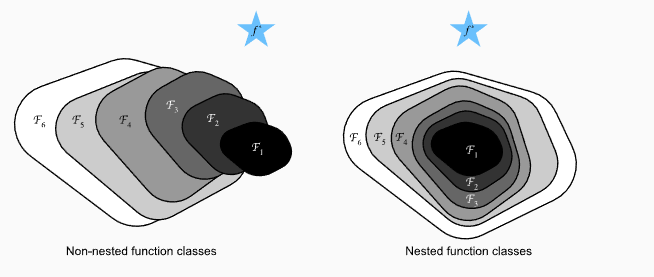

For non-nested function classes, a larger function class does not guarantee we will get closer to the “truth” function. This does not happen in nested function classes

In the contrast, nested function classes (where each class is contained within the next) provide a more structured approach, ensuring that increasing complexity leads to better approximations of $f^*$.

Thus, only if larger function classes contain the smaller ones are we guaranteed that increasing them strictly increases the expressive power of the network. For deep neural networks, if we can train the newly-added layer into an identity function $f(x)=x$, the new model will be as effective as the original model. As the new model may get a better solution to fit the training dataset, the added layer might make it easier to reduce training errors.

The theory behind ResNet, introduced by He et al. (2016), is rooted in the idea that each additional layer in a deep network should more easily approximate the identity function $f(x)=x$. This allows networks to avoid degradation in performance as the depth increases. This design was a breakthrough in deep learning and has influenced many architectures like residual networks (ResNet) and even Transformers.

## Residual Blocks

Denote the input by $x$. We assume that $f(x)$, the desired underlying mapping we want to obtain by learning. The figure below shows the difference between the regular block (left) and the residual block (right).

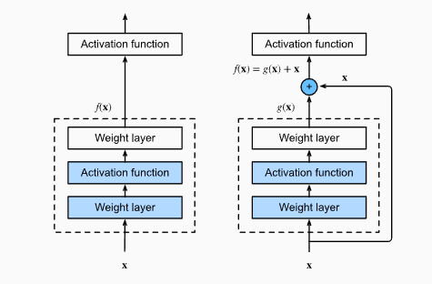

In a regular block (left), the portion within the dotted-line box must directly learn the mapping f(x). In a residual block (right), the portion within the dotted-line box needs to learn the residual mapping g(x)=f(x)-x, making the identity mapping easier to learn.

If the identity mapping $f(x)=x$ is the desired underlying mapping, the residual mapping amounts to $g(x)=0$ and it is thus easier to learn: we only need to push the weights and biases of the upper weight layer (e.g., fully connected layer and convolutional layer) within the dotted-line box to zero.

With residual blocks, inputs can forward propagate faster through the residual connections across layers. In fact, the residual block can be thought of as a special case of the multi-branch Inception block: it has two branches one of which is the identity mapping. Let’s have a look at the code below.

```python
class Residual(nn.Module):
    """The Residual block of ResNet models."""
    def __init__(self, num_channels, use_1x1conv=False, strides=1):
        super().__init__()
        self.conv1 = nn.LazyConv2d(num_channels, kernel_size=3, padding=1,
                                   stride=strides)
        self.conv2 = nn.LazyConv2d(num_channels, kernel_size=3, padding=1)
        if use_1x1conv:
            self.conv3 = nn.LazyConv2d(num_channels, kernel_size=1,
                                       stride=strides)
        else:
            self.conv3 = None
        self.bn1 = nn.LazyBatchNorm2d()
        self.bn2 = nn.LazyBatchNorm2d()

    def forward(self, X):
        Y = F.relu(self.bn1(self.conv1(X)))
        Y = self.bn2(self.conv2(Y))
        if self.conv3:
            X = self.conv3(X)
        Y += X
        return F.relu(Y)
```

Now let’s look at a situation where the input and output are of the same shape, where $1 \times 1$ convolution is not needed.

```python
blk = Residual(3)
X = torch.randn(4, 3, 6, 6)
blk(X).shape
```

```
torch.Size([4, 3, 6, 6])
```

We also have the option to halve the output height and width while increasing the number of output channels.

```python
blk = Residual(6, use_1x1conv=True, strides=2)
blk(X).shape
```

```
torch.Size([4, 6, 3, 3])
```

## ResNet Model

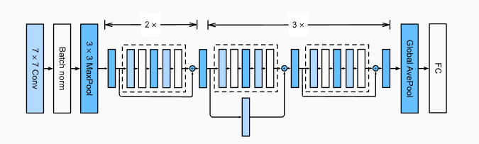

The ResNet-18 architecture

```python
class ResNet(d2l.Classifier):
    def b1(self):
        return nn.Sequential(
            nn.LazyConv2d(64, kernel_size=7, stride=2, padding=3),
            nn.LazyBatchNorm2d(), nn.ReLU(),
            nn.MaxPool2d(kernel_size=3, stride=2, padding=1))
    def block(self, num_residuals, num_channels, first_block=False):
        blk = []
        for i in range(num_residuals):
            if i == 0 and not first_block:
                blk.append(Residual(num_channels, use_1x1conv=True, strides=2))
            else:
                blk.append(Residual(num_channels))
        return nn.Sequential(*blk)
    def __init__(self, arch, num_classes=10):
        super(ResNet, self).__init__()
        self.save_hyperparameters()
        self.net = nn.Sequential(self.b1())
        for i, b in enumerate(arch):
            self.net.add_module(f'b{i+2}', self.block(*b, first_block=(i==0)))
        self.net.add_module('last', nn.Sequential(
            nn.AdaptiveAvgPool2d((1, 1)), nn.Flatten(),
            nn.LazyLinear(num_classes)))

class ResNet18(ResNet):
    def __init__(self, num_classes=10):
        super().__init__(((2, 64), (2, 128), (2, 256), (2, 512)),
                    num_classes)
    def layer_summary(self, X_shape):
        X = torch.randn(*X_shape)
        for layer in self.net:
            X = layer(X)
            print(layer.__class__.__name__, 'output shape:\t', X.shape)

ResNet18().layer_summary((1, 1, 96, 96))
```

```
Sequential output shape:     torch.Size([1, 64, 24, 24])
Sequential output shape:     torch.Size([1, 64, 24, 24])
Sequential output shape:     torch.Size([1, 128, 12, 12])
Sequential output shape:     torch.Size([1, 256, 6, 6])
Sequential output shape:     torch.Size([1, 512, 3, 3])
Sequential output shape:     torch.Size([1, 10])
```

## Training

```python
train_iter, test_iter, train_len, test_len = ImgDataloader(config_ResNet, shape=(96,96))
model = ResNet18()
trainer(train_iter, test_iter, train_len, test_len, model, config_ResNet, device)
```

```
training on cuda
[001/010] 13.62 sec(s) Train Acc: 0.855783 Loss: 0.391816 | Test Acc: 0.890200 loss: 0.295374
[002/010] 13.37 sec(s) Train Acc: 0.906550 Loss: 0.255273 | Test Acc: 0.870900 loss: 0.352110
[003/010] 13.33 sec(s) Train Acc: 0.921833 Loss: 0.213325 | Test Acc: 0.885100 loss: 0.314054
[004/010] 13.45 sec(s) Train Acc: 0.931667 Loss: 0.188048 | Test Acc: 0.908800 loss: 0.256173
[005/010] 13.45 sec(s) Train Acc: 0.940567 Loss: 0.161880 | Test Acc: 0.905500 loss: 0.263297
[006/010] 13.47 sec(s) Train Acc: 0.947217 Loss: 0.144362 | Test Acc: 0.915300 loss: 0.229455
[007/010] 13.47 sec(s) Train Acc: 0.953400 Loss: 0.125127 | Test Acc: 0.926000 loss: 0.217750
[008/010] 13.47 sec(s) Train Acc: 0.961233 Loss: 0.103946 | Test Acc: 0.916400 loss: 0.262016
[009/010] 13.53 sec(s) Train Acc: 0.967767 Loss: 0.085593 | Test Acc: 0.927100 loss: 0.249708
[010/010] 13.54 sec(s) Train Acc: 0.973750 Loss: 0.070590 | Test Acc: 0.930600 loss: 0.251504
```

What a good performance!

# Densely Connected Networks (DenseNet)

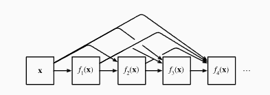

Dense connections in DenseNet. Note how the dimensionality increases with depth

The main components that comprise a DenseNet are dense blocks and transition layers. The former define how the inputs and outputs are concatenated, while the latter control the number of channels so that it is not too large.

## Dense Blocks

DenseNet uses the modified “batch normalization, activation, and convolution” structure of ResNet. First, we implement this convolution block structure.

```python
def conv_block(num_channels):
    return nn.Sequential(
        nn.LazyBatchNorm2d(), nn.ReLU(),
        nn.LazyConv2d(num_channels, kernel_size=3, padding=1))
```

A dense block consists of multiple convolution blocks, each using the same number of output channels. In the forward propagation, however, we concatenate the input and output of each convolution block on the channel dimension.

```python
class DenseBlock(nn.Module):
    def __init__(self, num_convs, num_channels):
        super(DenseBlock, self).__init__()
        layer = []
        for i in range(num_convs):
            layer.append(conv_block(num_channels))
        self.net = nn.Sequential(*layer)

    def forward(self, X):
        for blk in self.net:
            Y = blk(X)
            # Concatenate input and output of each block along the channels
            X = torch.cat((X, Y), dim=1)
        return X

blk = DenseBlock(2, 10)
X = torch.randn(4, 3, 8, 8)
Y = blk(X)
Y.shape
```

```
torch.Size([4, 23, 8, 8])
```

## Transition Layers

Since each dense block will increase the number of channels, adding too many of them will lead to an excessively complex model. A transition layer is used to control the complexity of the model. It reduces the number of channels by using a $1 \times 1$ convolution. Moreover, it halves the height and width via average pooling with a stride of 2.

```python
def transition_block(num_channels):
    return nn.Sequential(
        nn.LazyBatchNorm2d(), nn.ReLU(),
        nn.LazyConv2d(num_channels, kernel_size=1),
        nn.AvgPool2d(kernel_size=2, stride=2))

blk = transition_block(10)
blk(Y).shape
```

```
torch.Size([4, 10, 4, 4])
```

## DenseNet Model

Next, we will construct a DenseNet model. DenseNet first uses the same single convolutional layer and max-pooling layer as in ResNet.

```python
class DenseNet(d2l.Classifier):
    def b1(self):
        return nn.Sequential(
            nn.LazyConv2d(64, kernel_size=7, stride=2, padding=3),
            nn.LazyBatchNorm2d(), nn.ReLU(),
            nn.MaxPool2d(kernel_size=3, stride=2, padding=1))
    def __init__(self, num_channels=64, growth_rate=32, arch=(4, 4, 4, 4), num_classes=10):
        super(DenseNet, self).__init__()
        self.save_hyperparameters()
        self.net = nn.Sequential(self.b1())
        for i, num_convs in enumerate(arch):
            self.net.add_module(f'dense_blk{i+1}', DenseBlock(num_convs,
                                                            growth_rate))
            # The number of output channels in the previous dense block
            num_channels += num_convs * growth_rate
            # A transition layer that halves the number of channels is added
            # between the dense blocks
            if i != len(arch) - 1:
                num_channels //= 2
                self.net.add_module(f'tran_blk{i+1}', transition_block(
                    num_channels))
        self.net.add_module('last', nn.Sequential(
            nn.LazyBatchNorm2d(), nn.ReLU(),
            nn.AdaptiveAvgPool2d((1, 1)), nn.Flatten(),
            nn.LazyLinear(num_classes)))
        self.net.apply(d2l.init_cnn)
    def layer_summary(self, X_shape):
        X = torch.randn(*X_shape)
        for layer in self.net:
            X = layer(X)
            print(layer.__class__.__name__, 'output shape:\t', X.shape)

DenseNet().layer_summary((1, 1, 96, 96))
```

```
Sequential output shape:     torch.Size([1, 64, 24, 24])
DenseBlock output shape:     torch.Size([1, 192, 24, 24])
Sequential output shape:     torch.Size([1, 96, 12, 12])
DenseBlock output shape:     torch.Size([1, 224, 12, 12])
Sequential output shape:     torch.Size([1, 112, 6, 6])
DenseBlock output shape:     torch.Size([1, 240, 6, 6])
Sequential output shape:     torch.Size([1, 120, 3, 3])
DenseBlock output shape:     torch.Size([1, 248, 3, 3])
Sequential output shape:     torch.Size([1, 10])
```

## Training

```python
train_iter, test_iter, train_len, test_len = ImgDataloader(config_DenseNet, shape=(96,96))
model = DenseNet()
trainer(train_iter, test_iter, train_len, test_len, model, config_DenseNet, device)
```

```
training on cuda
[001/010] 13.39 sec(s) Train Acc: 0.845817 Loss: 0.423481 | Test Acc: 0.863200 loss: 0.373029
[002/010] 13.33 sec(s) Train Acc: 0.901417 Loss: 0.269061 | Test Acc: 0.888600 loss: 0.300533
[003/010] 13.36 sec(s) Train Acc: 0.915783 Loss: 0.229440 | Test Acc: 0.908300 loss: 0.252421
[004/010] 13.37 sec(s) Train Acc: 0.925083 Loss: 0.201959 | Test Acc: 0.922700 loss: 0.215622
[005/010] 13.47 sec(s) Train Acc: 0.931550 Loss: 0.186588 | Test Acc: 0.915800 loss: 0.227757
[006/010] 13.37 sec(s) Train Acc: 0.934933 Loss: 0.175360 | Test Acc: 0.920800 loss: 0.216912
[007/010] 13.35 sec(s) Train Acc: 0.940267 Loss: 0.160681 | Test Acc: 0.918700 loss: 0.228405
[008/010] 13.37 sec(s) Train Acc: 0.944550 Loss: 0.149499 | Test Acc: 0.923900 loss: 0.206656
[009/010] 13.33 sec(s) Train Acc: 0.947800 Loss: 0.140068 | Test Acc: 0.913300 loss: 0.247886
[010/010] 13.38 sec(s) Train Acc: 0.952850 Loss: 0.127041 | Test Acc: 0.930100 loss: 0.200575
```

Back to top